# **Lab 2:** Modelling & Model Error

By: Salvin Chowdhury

In this lab, we'll be investigating two commonly used models and the data that these models attempt to replicate. The purpose is to build familiarity with the different parts of the model and appreciate shared themes and commonalities between models.

The two models used in this lab are the gaussian distribution and a multi-dimensional linear model. By adjusting the model parameters, it is possible to change the relationship between independent variable (feature) input and the dependent variable (response) output.

```python
# importing the neceesary libraries
import pandas as pd
from typing import List
import matplotlib.pyplot as plt
import numpy as np
```

### Question 1

**Describe the relationship between the number of independent variables, dependent variables, and model parameters. If there is no dependence between them, please state this and discuss why this might be or what implications it has.**

In experiment 1, the dependent variable f(x) depends non-linearly on the independent variable x. For a gaussian PDF, changing the $\mu$ shifts the peak of the bell curve and changing the sigma changes the spread of the curve.

In experiment 2, the dependent variable (sales) depends linearly on all independent variables (Offset, TV, Radio, Newspaper). Each independent variable has a corresponding coefficient (beta) with the addition of an intercept.

### Question 2

**For this lab you were given datasets that had paired independent and dependent variables (supervised data).**

- **What would your model do if you gave it an independent variable value not from this dataset?**
- **Do you think the resulting output would be correct?**
- **How can you be sure?**

To answer this question again, we need to look at what we're doing for experiment 1 and experiment 2. In both experiments, our models were trained on a dataset. If we were to provide a independent variable that wasn't from the dataset, the Gaussian PDF will compute a new value using the provided $\mu$ and $\sigma$ values. The Linear Regression model will also compute a new value using the coefficient and as long as there are other new input values along with the new independent variable value.

The resulting output might and might not be correct. This is because the model is only trained on the provided dataset. Linear regression models predict in a linear manner, which is unrealistic. For the Gaussian PDF, it's center depends on $\mu$ and the spread is according to $\sigma$. If our new independent value has a large difference from the $\mu$, then we would get a very small value as the output. The computations may be correct, but it might not reflect what the real world might expect.

To be sure, we need to perform validation on our model, by having our model give out predictions on unseen data and compare the predictions to the true values. If the model performs with a high accuracy for its predictions, this means we can be sure that our resulting output from a independent value not from the dataset is correct.

### Question 3

**You used mean absolute error to quantify the difference between your given data and model predictions. Lookup (either online or from your textbook) another metric used to quantify error.**

- **Compare and contrast this new metric with mean absolute error.**
- **Discuss what you think the advantages/disadvantages might be between MAE and your other metric. Hint: What shape do different error functions have as you change model parameters to get predictions that are closer to your observed data?**

Another metric used to quantify error is the mean squared error. The MSE value provides a way to analyze the accuracy of the model. It measures the average average squared difference between the predicted and actual values in the dataset.

Some Advantages & Disadvantages of MSE:

- **Advantage:** the MSE leads to a stable convergence of the model, as the mean square difference between predictions and actual values is minimized
- **Disadvantage:** if datasets contain outliers that the model can't predict well, the MSE may be a poor loss function as it doesn't accurately reflect the predictive quality of the model

Some Advantages & Disadvantages of MAE:

- **Advantage:** MAE is very robust regarding outliers, as MAE tends to calculate the absolute differences between the predicted and actual values
- **Disadvantage:** MAE focuses more on the magnitude of the error rather than its direction, which means it can neglect systemic bias of the model

In MAE, the error function is piecewise linear with respect to each parameter. For the MSE, the error function is quadratic with respect to each error. Keeping the advantages and disadvantages mentioned above in mind, the shapes make sense because

- For MAE, there can be flat regions around small errors, which means slower convergence
- For MSE, there can be smooth parabolas, which means it is very sensitive to outliers

Sources Used:

- https://www.geeksforgeeks.org/maths/mean-squared-error/
- https://databasecamp.de/en/statistics/mean-squared-error
- https://medium.com/@muhammadhassan1762005/mae-mean-absolute-error-in-machine-learning-e678cc7bb8d4

### Question 4

**We had you plot multiple figures for experiment 2.**

- **Can you think of a way to plot 2 independent variables and the dependent variable on the same plot?**
- **What about a way to visualize 3 independent variables and the dependent variable on the same plot? 4 and 1?**
- **What about a way to visualize a dataset of 100 features and 1 dependent variable on the same plot?**
- **With these plots in mind, describe how the error metric can help.**

To plot 2 independent variables and the dependent variable, this would mean plotting 3 parameters, and a fitting way to plot that would be using a 3D scatter plot.

To plot 3 independent variables and the dependent variable, this would mean plotting 4 parameters. One method would be to plot a 4 dimensional plot, but this can be hard to interpret. However, another possible method would be pair plots, which would be much more easier to interpret.

To plot 100 features and 1 dependent variable, it would not be feasible to create 101 dimensional plot. Instead, it would be necessary to perform dimensionality reduction, such as Principal Component Analysis and the plotting the PCA by plotting the components on the x and y axis.

The error metric is helpful because sometimes analyzing plots can require a lot of mental effort, but a much easier way to know if your model is performing well is by using error metrics like MAE and MSE, which provides an idea on the prediction accuracy of the model.

### Question 5

How well did the model parameter sets you chose for experiment 2 perform?

- **With the methods and tools that you have at your disposal, can you think of a more structured way to find a good set of parameters rather than picking a set and checking?**
- **Hint: It is relatively inexpensive to evaluate these models. How could you use a loop, or set of loops, to find a set of model parameters that have low error?**

With regards to the performance of the model parameters, the parameters in beta two performed better than beta one because the mean absolute error value was lower than the mean absolute error for the parameters in beta one. To find a set of model parameters that have low error, we can use for loops to loop through different values for each paramter in a beta and then compute the mean absolute error. The beta with the set of parameter with the lowest MAE would be the best set of model parameters.

## **Experiment 1:** Gaussian Distribution

The Gaussian Distribution is a way to describe how data points are spread out. It makes a bell-shaped curve when drawn on a graph.

### **Part 1:** Given Data

In this part, we achieve the following checklist items:

- Load the `gaussdist.csv` into your notebook.
- Identify the columns associated with the response variable and the feature variable.
- The features and response variables should be stored in separate numpy arrays.
- Plot the feature (x-axis) versus the response (y-axis) of the gaussdist.csv dataset. Make sure to label your plot.|

```
Feature One Minimum:  0.04
Feature One Maximum:  9.88
Feature Two Minimum:  2.29591482455821e-05
Feature Two Maximum:  0.319153824321146
```

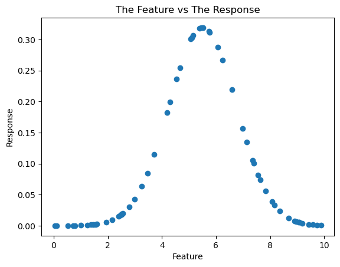

```python
# importing the .csv file
gauss_df = pd.read_csv("data/gaussdist.csv", header=None, names=["1", "2"])

# finding the range of the values
print("Feature One Minimum: ", gauss_df["1"].min())
print("Feature One Maximum: ", gauss_df["1"].max())
print("Feature Two Minimum: ", gauss_df["2"].min())
print("Feature Two Maximum: ", gauss_df["2"].max())

# from the results above -> feature 1 is feature variable & feature 2 is response variable

# creating new numpy arrays to store the data in
feature_array = np.array(gauss_df['1'])
response_array =np.array(gauss_df['2'])

# plotting the feature variable against the response variable
plt.scatter(feature_array, response_array)
plt.title("The Feature vs The Response")
plt.xlabel("Feature")
plt.ylabel("Response")
plt.show()
```

### **Part 2:** Model Familiarity

In a new cell, use markdown to write out the mathematical form of the Gaussian Distribution Probability Density Function. In the same cell, identify the following:

- Model Parameters
- Independent Variables
- Dependent Variables

### The Gaussian Distribution Probability Density Function

$$f(x) = \frac{1}{\sigma\sqrt{2\pi}} e^{-\frac{(x - \mu)^2}{2 \sigma^2}}$$

In this probability density function, the model parameters are $\mu$ and $\sigma$ The independent variables are x and the dependent variables are f(x).

### **Part 3:** Model Implementation

Implement the gaussian distribution model. The code should operate on the independent variable and "fixed" model parameters to produce the dependent variable as output. To start off, the code should be able to take a single independent variable (scalar) and produce a single dependent variable (scalar), but ultimately, it should support the use of vector input / output.

```python
# defining a method based on the gaussian distribution pdf
# ! need to change this to accept vectors

def gaussian_pdf_plot(input_val: np.ndarray, mu: float, sigma: float) -> np.ndarray:

    """
        this is a method that returns a numpy array of the predictions being made
    """

    part_one = 1 / (sigma * np.sqrt(2 * np.pi))
    part_two = -1 * (input_val - mu)**2 / (2 * sigma**2)
    final_val = part_one * (np.exp(part_two))

    return final_val
```

### **Part 4:** Model Output and Visualization

Use the coded model to generate model predictions (output) using the dataset's independent variable values. On the same figure, plot the model predictions from the following set of model parameters and the given data.

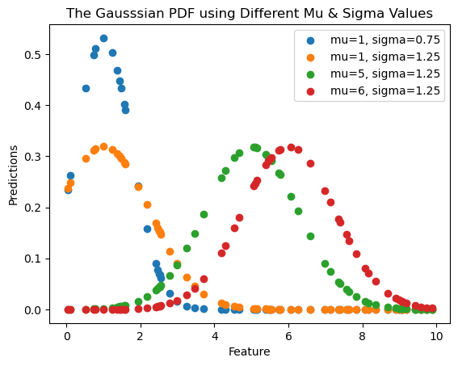

```python
array_one = gaussian_pdf_plot(gauss_df["1"], 1, 0.75)
array_two = gaussian_pdf_plot(gauss_df["1"], 1, 1.25)
array_three = gaussian_pdf_plot(gauss_df["1"], 5, 1.25)
array_four = gaussian_pdf_plot(gauss_df["1"], 6, 1.25)

plt.scatter(gauss_df["1"], array_one, label="mu=1, sigma=0.75")
plt.scatter(gauss_df["1"], array_two, label="mu=1, sigma=1.25")
plt.scatter(gauss_df["1"], array_three, label="mu=5, sigma=1.25")
plt.scatter(gauss_df["1"], array_four, label="mu=6, sigma=1.25")

plt.title("The Gausssian PDF using Different Mu & Sigma Values")
plt.xlabel("Feature")
plt.ylabel("Predictions")

plt.legend()
plt.show()
```

### Part 5: Error Between Model and Data

Each plot that was produced depics the data that was given and data that the model produced for a given set of parameters. The goal is choose a set of parameters that minimizes the difference between the model output and the given data. The difference between those two sets is known as the model error.

A common metric used to quantify error is known as the Mean Absolute Error. We use this metric to characterize the error between the model and the given data. Here are the following deliverables:

- Use markdown to write out the mathematical form of Mean Abbsolute Error. We use this metric to characterize the error between the model and the given data.
- For each set of model predictions (4 sets – 1 for each parameter set), calculate the mean absolute error between the model prediction and the given data.
- Plot all of the model predictions and the given data in a new figure and add the calculated error values to the figure legend.

### The Mean Absolute Error Formula

$$ MAE = \frac{1}{n} \sum_{i=1}^{n} | x_i - x | $$

```python
# defining a function that calculates the mean absolte error

def compute_mae(array_one: np.ndarray, array_two: np.ndarray) -> float:

    """
        this is a method that computes the mean absolute error and returns it as a float
    """

    difference = np.abs(np.subtract(array_one, array_two))
    difference_sum = np.sum(difference)
    mean_square_error = (1 / len(array_one)) * difference_sum
    return mean_square_error
```

```python
# the mean absolute error list
mae_list = []

# computing the mean absolute error and appending
mae_list.append(compute_mae(gauss_df["2"], array_one))
mae_list.append(compute_mae(gauss_df["2"], array_two))
mae_list.append(compute_mae(gauss_df["2"], array_three))
mae_list.append(compute_mae(gauss_df["2"], array_four))

# printing out the results
print("All Mean Absolute Errors: ", mae_list)
```

```
All Mean Absolute Errors:  [np.float64(0.18937403173481707), np.float64(0.16922757281678635), np.float64(0.026490469979950224), np.float64(0.027470666663403025)]
```

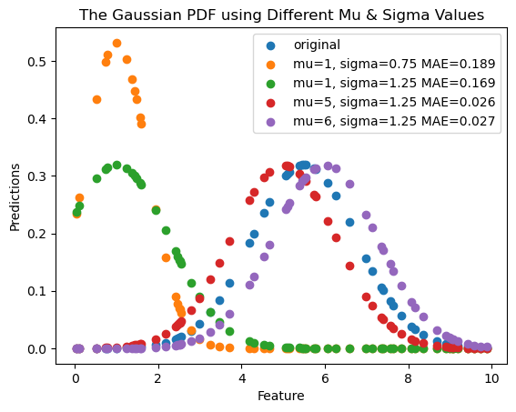

```python
# plotting with MAE in legend
plt.scatter(gauss_df["1"], gauss_df["2"], label="original")
plt.scatter(gauss_df["1"], array_one, label=f"mu=1, sigma=0.75 MAE={mae_list[0]:.3f}")
plt.scatter(gauss_df["1"], array_two, label=f"mu=1, sigma=1.25 MAE={mae_list[1]:.3f}")
plt.scatter(gauss_df["1"], array_three, label=f"mu=5, sigma=1.25 MAE={mae_list[2]:.3f}")
plt.scatter(gauss_df["1"], array_four, label=f"mu=6, sigma=1.25 MAE={mae_list[3]:.3f}")

# adding in the plot details
plt.title("The Gaussian PDF using Different Mu & Sigma Values")
plt.xlabel("Feature")
plt.ylabel("Predictions")
plt.legend()
plt.show()
```

## **Experiment 2:** Multiple Linear Regression Model

For this experiment, repeat each of the five steps as you did for experiment 1. To help, here is the additional information.

- Now, we use the `advertising.csv` dataset for the multiple linear regression model. The `Sales` variable will be the response variable that needs to be predicted. This means there is a 4-1 relationship between independent and dependent variables.
- When plotting the data and model output, you now have 4 independent variables and 1 dependent variable. In this lab, we use 2D plots to show the relationships between independent and independent variables and independent and dependent variables.
- When identifying the independent variables of the multiple linear regression, it may be helpful to label the variables using the variable names from the dataset. While this is not necessary, it may help with interpretability.

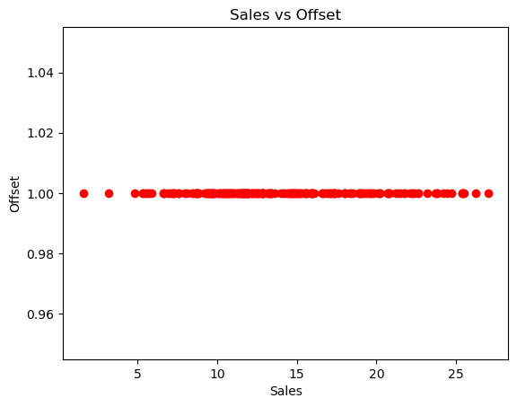

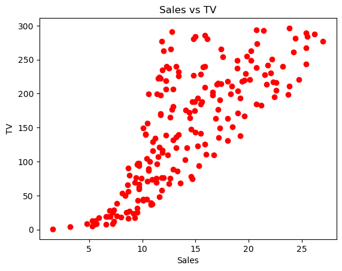

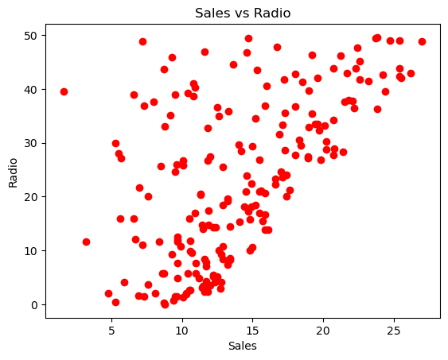

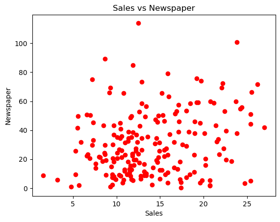

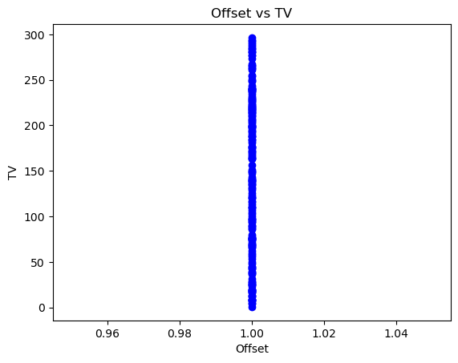

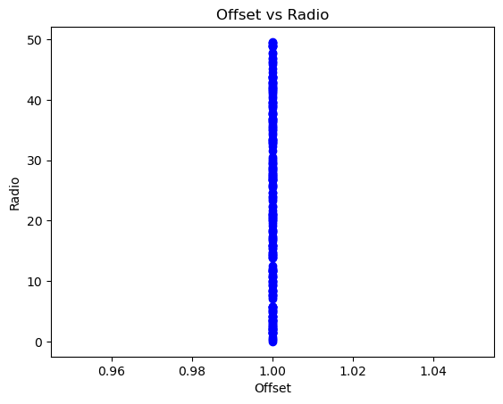

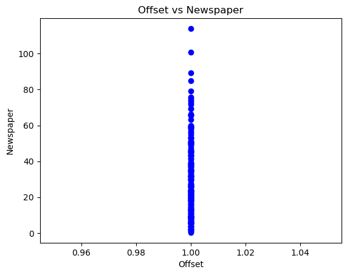

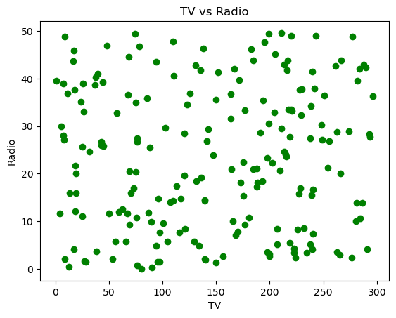

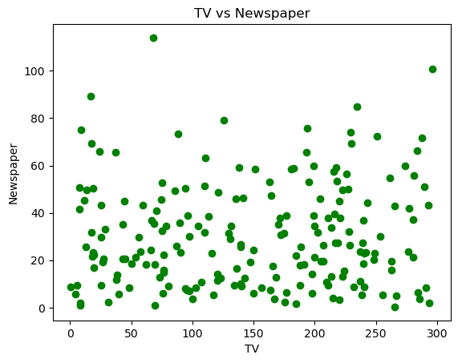

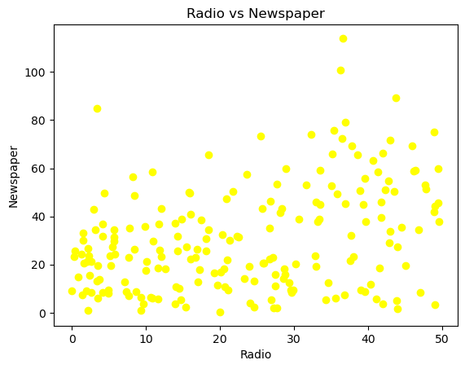

```python
# importing the .csv file
sales_df = pd.read_csv("data/advertising.csv")

# breaking the dataframe into five numpy arrays
sales_col = np.array(sales_df['sales'])
offset_col = np.array(sales_df['Offset'])
tv_col = np.array(sales_df['TV'])
radio_col = np.array(sales_df['radio'])
newspaper_col = np.array(sales_df['newspaper'])


def plot_scatter(array_one: np.ndarray, array_two: np.ndarray, label_one: str, label_two: str, color: str) -> None:

    """
        this is a method that plots out scatter plots for two numpy arrays
    """

    plt.scatter(array_one, array_two, color=color)
    plt.xlabel(label_one)
    plt.ylabel(label_two)
    plt.title(f"{label_one} vs {label_two}")
    plt.show()


# ! sales vs offset, tv, radio and newspaper
plot_scatter(sales_col, offset_col, "Sales", "Offset", "red")
plot_scatter(sales_col, tv_col, "Sales", "TV", "red")
plot_scatter(sales_col, radio_col, "Sales", "Radio", "red")
plot_scatter(sales_col, newspaper_col, "Sales", "Newspaper", "red")

# ! offset vs tv, radio and newspaper
plot_scatter(offset_col, tv_col, "Offset", "TV", "blue")
plot_scatter(offset_col, radio_col, "Offset", "Radio", "blue")
plot_scatter(offset_col, newspaper_col, "Offset", "Newspaper", "blue")

# ! tv vs radio and newspaper
plot_scatter(tv_col, radio_col, "TV", "Radio", "green")
plot_scatter(tv_col, newspaper_col, "TV", "Newspaper", "green")

# ! radio vs newspaper
plot_scatter(radio_col, newspaper_col, "Radio", "Newspaper", "yellow")
```

- We now pick the model parameters. We pick two sets of model parameters and plot the model predictions.

Here are the proposed model parameters:

| Parameter | Beta 1 | Beta 2 |
| --- | --- | --- |
| Intercept | 2 | 1 |
| Offset | 0.04 | 0.03 |
| TV | 0.3 | 0.2 |
| Radio | 0.2 | 0.1 |
| Newspaper | 0.1 | 0.05 |

```
39.838449999999995
20.292950000000005
```

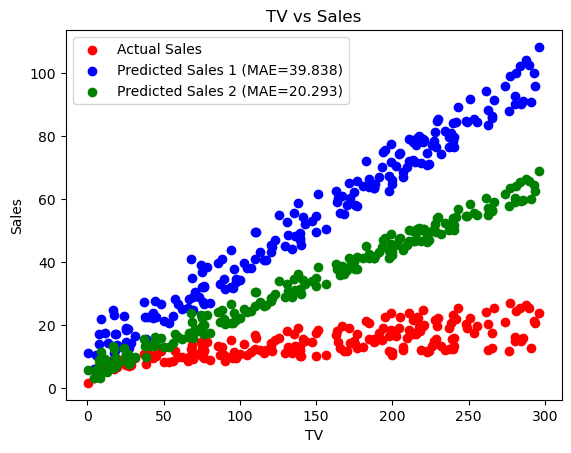

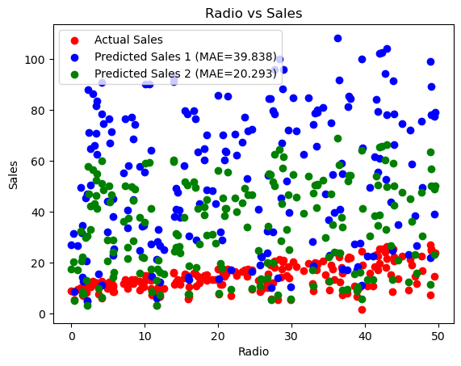

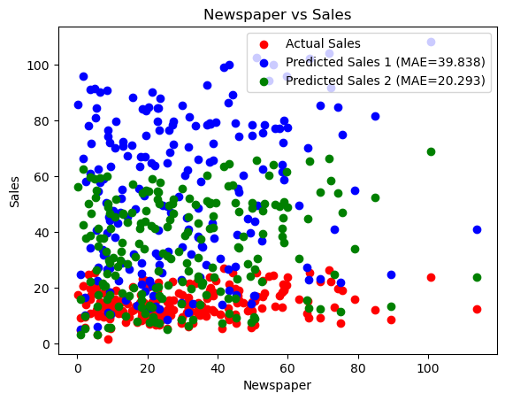

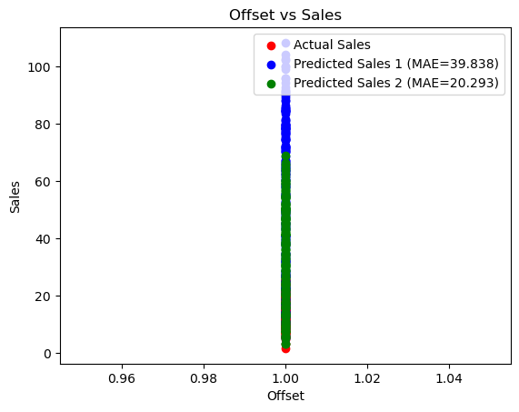

```python
# defining the weights and intercept
beta1 = [2, 0.04, 0.3, 0.2, 0.1]
beta2 = [1, 0.03, 0.2, 0.1, 0.05]

# computing the predicting sales values
pred_sales1 = (beta1[0] + beta1[1]*offset_col + beta1[2]*tv_col + beta1[3]*radio_col + beta1[4]*newspaper_col)
pred_sales2 = (beta2[0] + beta2[1]*offset_col + beta2[2]*tv_col + beta2[3]*radio_col + beta2[4]*newspaper_col)

# computing the mean absolute error
mae_one = compute_mae(sales_col, pred_sales1)
mae_two = compute_mae(sales_col, pred_sales2)

print(mae_one)
print(mae_two)

# plotting actual sales values versus the predicted sales value
def plot_actual_vs_pred(independent, actual, pred1, pred2, xlabel, mae1, mae2):
    plt.scatter(independent, actual, color='red', label='Actual Sales')
    plt.scatter(independent, pred1, color='blue', label=f'Predicted Sales 1 (MAE={mae1:.3f})')
    plt.scatter(independent, pred2, color='green', label=f'Predicted Sales 2 (MAE={mae2:.3f})')
    plt.xlabel(xlabel)
    plt.ylabel('Sales')
    plt.title(f'{xlabel} vs Sales')
    plt.legend()
    plt.show()

# calling the functions for dependent vs independent variables
plot_actual_vs_pred(tv_col, sales_col, pred_sales1, pred_sales2, 'TV', mae_one, mae_two)
plot_actual_vs_pred(radio_col, sales_col, pred_sales1, pred_sales2, 'Radio', mae_one, mae_two)
plot_actual_vs_pred(newspaper_col, sales_col, pred_sales1, pred_sales2, 'Newspaper', mae_one, mae_two)
plot_actual_vs_pred(offset_col, sales_col, pred_sales1, pred_sales2, 'Offset', mae_one, mae_two)
```